# Notebook

#### Checking if the prevailing wage is similar across all the regions of the US

```
### Prevailing Wage Across US Regions ###
```

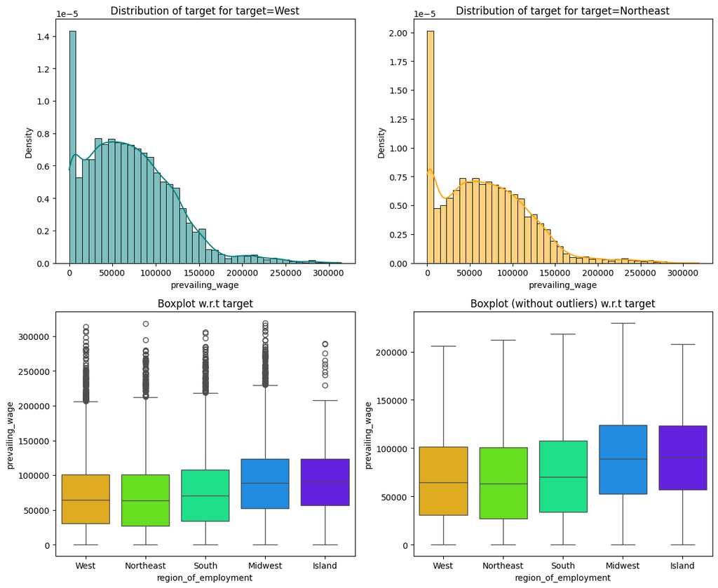

```python
# Prevailing Wage Across Different US Regions
print("\n### Prevailing Wage Across US Regions ###")
distribution_plot_wrt_target(data, "prevailing_wage", "region_of_employment")
```

• No, prevailing wages vary across US regions.

• Midwest and Island regions show higher median wages.

• West regions display lower median wages.

• All regions have outliers indicating very high wage offers exist everywhere.

• The boxplots show different interquartile ranges, suggesting different wage distributions by region.

#### The US government has established a prevailing wage to protect local talent and foreign workers. Let's analyze the data and see if the visa status changes with the prevailing wage

```
### Impact of Prevailing Wage on Visa Certification ###
```

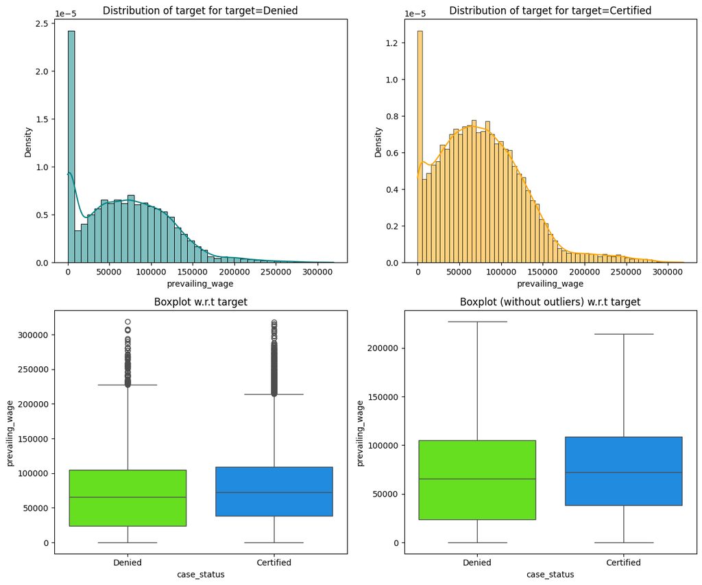

```python
# Impact of Prevailing Wage on Visa Status
print("\n### Impact of Prevailing Wage on Visa Certification ###")
distribution_plot_wrt_target(data, "prevailing_wage","case_status")
```

• Yes, visa status does change with prevailing wage.

• Certified applications tend to have higher prevailing wages on average.

• The distribution patterns differ between certified and denied applications.

• Boxplots show certified applications have a higher median wage than denied ones.

• The histograms show different density patterns for certified versus denied applications.